# Data Analysis on Students’ Technology Acceptance of Moodle and Academic Discipline

Laura Reinhardt

2024-04-18

# Data Analysis on Students’ Technology Acceptance of Moodle and Academic Discipline

## Data Preparation

```r
#install.packages("here")
library(here)
here()
```

```
## [1] "C:/Users/laura/Documents/AI/technology-acceptance"
```

```r
data <- read.csv2(here("data", "data_tastudents.csv"), encoding="UTF-8", fileEncoding="latin1") # import data
```

I have read in the data after having manually deleted unnecessary columns via Excel (time spent per page, and so on.)

```r
dim(data) # make sure correct number of columns and rows were imported
```

```
## [1] 68 35
```

```r
str(data) # check data types
```

```
## 'data.frame':    68 obs. of  35 variables:
##  $ ï..ID  : int  1 2 3 4 5 6 7 8 9 10 ...
##  $ AD01   : int  1 1 1 1 1 1 1 1 1 1 ...
##  $ AD02   : int  1 1 1 -9 1 1 1 2 1 1 ...
##  $ AD03   : int  1 1 1 4 9 1 9 1 3 6 ...
##  $ AT01_01: int  2 4 3 4 2 3 3 3 5 2 ...
##  $ AT01_02: int  2 3 3 3 1 3 3 3 4 2 ...
##  $ AT01_03: int  3 3 3 4 1 3 3 4 5 2 ...
##  $ AT01_04: int  4 3 3 3 2 3 3 3 2 2 ...
##  $ AU01_01: int  3 4 3 5 4 4 4 3 5 3 ...
##  $ AU01_02: int  3 4 4 5 4 4 4 3 5 3 ...
##  $ AU01_03: int  3 4 4 5 4 4 4 3 5 3 ...
##  $ AU02   : int  1 1 1 1 1 1 1 1 1 1 ...
##  $ BI01_01: int  4 4 2 4 3 5 3 3 4 3 ...
##  $ BI01_02: int  4 3 2 2 3 3 3 4 3 2 ...
```

[output cut: 21 more lines]

```r
anyNA(data) # no initial NA values
```

```
## [1] FALSE
```

```r
for (i in 1:nrow(data)) { # loop through all rows and columns to replace empty values that are coded as -9 as actual NA that are recognized by R
  for (j in 1:ncol(data)) {
    if (data[i, j] == -9) {
      data[i, j] <- NA
    }
  }
}
```

```r
anyNA(data)
```

```
## [1] TRUE
```

```r
colSums(is.na(data)) # check which columns contain NAs
```

```
##   ï..ID    AD01    AD02    AD03 AT01_01 AT01_02 AT01_03 AT01_04 AU01_01 AU01_02
##       0       0       1       0       0       0       0       0       0       0
## AU01_03    AU02 BI01_01 BI01_02 BI01_03 BI01_04 BI01_05    DE02    DE03 OT01_02
##       0       0       0       0       0       0       0       2       1       0
## PE01_01 PE01_02 PE01_03 PE01_04 PE01_05 PE01_06 PU01_01 PU01_02 PU01_03 PU01_04
##       0       0       0       0       0       0       0       0       0       0
## PU01_05 PU01_06 VU01_01 VU01_02 VU01_03
##       0       0       0       0       0
```

One person didn’t select what type of degree they are pursuing, two people did not select their gender and one person did not disclose their age. Since I cannot afford to lose their other replies, I will add an extra level “other” to these three columns. First, of course, I have to change the class of the columns to factors first.

```r
colnames(data)[1] <- "ID" # rename first column to ID since name got corrupted during the import process
colnames(data)
```

```
##  [1] "ID"      "AD01"    "AD02"    "AD03"    "AT01_01" "AT01_02" "AT01_03"
##  [8] "AT01_04" "AU01_01" "AU01_02" "AU01_03" "AU02"    "BI01_01" "BI01_02"
## [15] "BI01_03" "BI01_04" "BI01_05" "DE02"    "DE03"    "OT01_02" "PE01_01"
## [22] "PE01_02" "PE01_03" "PE01_04" "PE01_05" "PE01_06" "PU01_01" "PU01_02"
## [29] "PU01_03" "PU01_04" "PU01_05" "PU01_06" "VU01_01" "VU01_02" "VU01_03"
```

First, I changed the name of the first column to ID, since the name seems to have gotten corrupted during the import process.

```r
str(data)
```

```
## 'data.frame':    68 obs. of  35 variables:
##  $ ID     : int  1 2 3 4 5 6 7 8 9 10 ...
##  $ AD01   : int  1 1 1 1 1 1 1 1 1 1 ...
##  $ AD02   : int  1 1 1 NA 1 1 1 2 1 1 ...
##  $ AD03   : int  1 1 1 4 9 1 9 1 3 6 ...
##  $ AT01_01: int  2 4 3 4 2 3 3 3 5 2 ...
##  $ AT01_02: int  2 3 3 3 1 3 3 3 4 2 ...
##  $ AT01_03: int  3 3 3 4 1 3 3 4 5 2 ...
##  $ AT01_04: int  4 3 3 3 2 3 3 3 2 2 ...
##  $ AU01_01: int  3 4 3 5 4 4 4 3 5 3 ...
##  $ AU01_02: int  3 4 4 5 4 4 4 3 5 3 ...
##  $ AU01_03: int  3 4 4 5 4 4 4 3 5 3 ...
##  $ AU02   : int  1 1 1 1 1 1 1 1 1 1 ...
##  $ BI01_01: int  4 4 2 4 3 5 3 3 4 3 ...
##  $ BI01_02: int  4 3 2 2 3 3 3 4 3 2 ...
```

[output cut: 21 more lines]

```r
# correct data types
data$AD01 <- factor(data$AD01)
data$AD02 <- factor(data$AD02)
data$AD03 <- factor(data$AD03)
data$AU02 <- factor(data$AU02)
data$DE02 <- factor(data$DE02)
data$DE03 <- factor(data$DE03)

str(data)
```

```
## 'data.frame':    68 obs. of  35 variables:
##  $ ID     : int  1 2 3 4 5 6 7 8 9 10 ...
##  $ AD01   : Factor w/ 1 level "1": 1 1 1 1 1 1 1 1 1 1 ...
##  $ AD02   : Factor w/ 2 levels "1","2": 1 1 1 NA 1 1 1 2 1 1 ...
##  $ AD03   : Factor w/ 9 levels "1","2","3","4",..: 1 1 1 4 9 1 9 1 3 6 ...
##  $ AT01_01: int  2 4 3 4 2 3 3 3 5 2 ...
##  $ AT01_02: int  2 3 3 3 1 3 3 3 4 2 ...
##  $ AT01_03: int  3 3 3 4 1 3 3 4 5 2 ...
##  $ AT01_04: int  4 3 3 3 2 3 3 3 2 2 ...
##  $ AU01_01: int  3 4 3 5 4 4 4 3 5 3 ...
##  $ AU01_02: int  3 4 4 5 4 4 4 3 5 3 ...
##  $ AU01_03: int  3 4 4 5 4 4 4 3 5 3 ...
##  $ AU02   : Factor w/ 2 levels "1","2": 1 1 1 1 1 1 1 1 1 1 ...
##  $ BI01_01: int  4 4 2 4 3 5 3 3 4 3 ...
##  $ BI01_02: int  4 3 2 2 3 3 3 4 3 2 ...
```

[output cut: 21 more lines]

Now I will treat the missing data that was previously found. NA are in the columns AD02, DE02 and DE03.

```r
# add "Other" level to some factors
levels(data$AD02) <- c(levels(data$AD02), "Other")
levels(data$DE02) <- c(levels(data$DE02), "Other")
levels(data$DE03) <- c(levels(data$DE03), "Other")

# change NAs to "Other" value
data$AD02[is.na(data$AD02)] <- "Other"
data$DE02[is.na(data$DE02)] <- "Other"
data$DE03[is.na(data$DE03)] <- "Other"

# check that there are no more NAs
colSums(is.na(data))
```

```
##      ID    AD01    AD02    AD03 AT01_01 AT01_02 AT01_03 AT01_04 AU01_01 AU01_02
##       0       0       0       0       0       0       0       0       0       0
## AU01_03    AU02 BI01_01 BI01_02 BI01_03 BI01_04 BI01_05    DE02    DE03 OT01_02
##       0       0       0       0       0       0       0       0       0       0
## PE01_01 PE01_02 PE01_03 PE01_04 PE01_05 PE01_06 PU01_01 PU01_02 PU01_03 PU01_04
##       0       0       0       0       0       0       0       0       0       0
## PU01_05 PU01_06 VU01_01 VU01_02 VU01_03
##       0       0       0       0       0
```

The missing data has been successfully dealt with. Now I want to find the average values of attitude towards using Moodle, actual use of Moodle, behavioral intention to use Moodle, perceived ease of use, perceived usefulness and voluntariness. First, I have to deal with two negation statements in AT and VU. I will do this by adding an extra variable for each where I switch the values. AT, for example, has three statements where a high number indicates positive attitude and one where a high number indicates negative attitude. In order to use the mean value for the testing, a high number has to indicate a positive attitude for all statements. The same applies to VU.

```r
# introduce  variable AT01_04R to indicate it is reworked
data$AT01_04R[data$AT01_04 == 3] <- 3 # neither agree or disagree stays the same
data$AT01_04R[data$AT01_04 == 2] <- 4 # disagree becomes agree
data$AT01_04R[data$AT01_04 == 1] <- 5 # strongly disagree becomes strongly agree
data$AT01_04R[data$AT01_04 == 4] <- 2 # agree becomes disagree
data$AT01_04R[data$AT01_04 == 5] <- 1 # strongly agree becomes strongly disagree
as.integer(data$AT01_04R)
```

```
##  [1] 2 3 3 3 4 3 3 3 4 4 2 5 2 3 5 2 4 3 1 5 2 4 3 3 4 3 1 3 3 3 4 3 5 2 3 3 4 5
## [39] 3 5 3 4 2 3 4 3 3 3 5 3 3 3 3 3 5 3 4 3 2 4 3 3 5 2 4 2 4 2
```

```r
data$AT01_04R <- as.integer(data$AT01_04R)

head(data) # check that values are correct
```

```
##   ID AD01  AD02 AD03 AT01_01 AT01_02 AT01_03 AT01_04 AU01_01 AU01_02 AU01_03
## 1  1    1     1    1       2       2       3       4       3       3       3
## 2  2    1     1    1       4       3       3       3       4       4       4
## 3  3    1     1    1       3       3       3       3       3       4       4
## 4  4    1 Other    4       4       3       4       3       5       5       5
## 5  5    1     1    9       2       1       1       2       4       4       4
## 6  6    1     1    1       3       3       3       3       4       4       4
##   AU02 BI01_01 BI01_02 BI01_03 BI01_04 BI01_05 DE02 DE03
## 1    1       4       4       4       4       4    1    1
## 2    1       4       3       3       3       3    1    1
## 3    1       2       2       4       4       4    1    1
## 4    1       4       2       3       4       4    2    1
## 5    1       3       3       1       1       1    1    1
## 6    1       5       3       5       5       5    1    1
##                                   OT01_02 PE01_01 PE01_02 PE01_03 PE01_04
```

[output cut: 20 more lines]

```r
# introduce  variable VU01_01R to indicate it is reworked, higher number indicates lower voluntariness
data$VU01_01R[data$VU01_01 == 3] <- 3 # neither agree or disagree stays the same
data$VU01_01R[data$VU01_01 == 2] <- 4 # disagree becomes agree
data$VU01_01R[data$VU01_01 == 1] <- 5 # strongly disagree becomes strongly agree
data$VU01_01R[data$VU01_01 == 4] <- 2 # agree becomes disagree
data$VU01_01R[data$VU01_01 == 5] <- 1 # strongly agree becomes strongly disagree
data$VU01_01R <- as.integer(data$VU01_01R)

str(data)
```

```
## 'data.frame':    68 obs. of  37 variables:
##  $ ID      : int  1 2 3 4 5 6 7 8 9 10 ...
##  $ AD01    : Factor w/ 1 level "1": 1 1 1 1 1 1 1 1 1 1 ...
##  $ AD02    : Factor w/ 3 levels "1","2","Other": 1 1 1 3 1 1 1 2 1 1 ...
##  $ AD03    : Factor w/ 9 levels "1","2","3","4",..: 1 1 1 4 9 1 9 1 3 6 ...
##  $ AT01_01 : int  2 4 3 4 2 3 3 3 5 2 ...
##  $ AT01_02 : int  2 3 3 3 1 3 3 3 4 2 ...
##  $ AT01_03 : int  3 3 3 4 1 3 3 4 5 2 ...
##  $ AT01_04 : int  4 3 3 3 2 3 3 3 2 2 ...
##  $ AU01_01 : int  3 4 3 5 4 4 4 3 5 3 ...
##  $ AU01_02 : int  3 4 4 5 4 4 4 3 5 3 ...
##  $ AU01_03 : int  3 4 4 5 4 4 4 3 5 3 ...
##  $ AU02    : Factor w/ 2 levels "1","2": 1 1 1 1 1 1 1 1 1 1 ...
##  $ BI01_01 : int  4 4 2 4 3 5 3 3 4 3 ...
##  $ BI01_02 : int  4 3 2 2 3 3 3 4 3 2 ...
```

[output cut: 23 more lines]

```r
data[data$AU02 == 2,]
```

```
##    ID AD01 AD02 AD03 AT01_01 AT01_02 AT01_03 AT01_04 AU01_01 AU01_02 AU01_03
## 28 28    1    1    2       3       3       3       3       4       3       3
##    AU02 BI01_01 BI01_02 BI01_03 BI01_04 BI01_05 DE02 DE03         OT01_02
## 28    2       2       3       3       3       4    2    1 Tablet, laptop
##    PE01_01 PE01_02 PE01_03 PE01_04 PE01_05 PE01_06 PU01_01 PU01_02 PU01_03
## 28       5       4       4       4       4       4       4       4       4
##    PU01_04 PU01_05 PU01_06 VU01_01 VU01_02 VU01_03 AT01_04R VU01_01R
## 28       4       4       4       3       3       2        3        3
```

One participant indicates he does not have the opportunity to use Moodle, but this row also contains the information that Moodle is being used by the participant at least once a week (AU01_01, AU01_02, AU01_03), which means that this is likely a misclick or a misunderstanding. The row will not be excluded.

```r
# calculate mean of the variables and add as new column
str(data)
```

```
## 'data.frame':    68 obs. of  37 variables:
##  $ ID      : int  1 2 3 4 5 6 7 8 9 10 ...
##  $ AD01    : Factor w/ 1 level "1": 1 1 1 1 1 1 1 1 1 1 ...
##  $ AD02    : Factor w/ 3 levels "1","2","Other": 1 1 1 3 1 1 1 2 1 1 ...
##  $ AD03    : Factor w/ 9 levels "1","2","3","4",..: 1 1 1 4 9 1 9 1 3 6 ...
##  $ AT01_01 : int  2 4 3 4 2 3 3 3 5 2 ...
##  $ AT01_02 : int  2 3 3 3 1 3 3 3 4 2 ...
##  $ AT01_03 : int  3 3 3 4 1 3 3 4 5 2 ...
##  $ AT01_04 : int  4 3 3 3 2 3 3 3 2 2 ...
##  $ AU01_01 : int  3 4 3 5 4 4 4 3 5 3 ...
##  $ AU01_02 : int  3 4 4 5 4 4 4 3 5 3 ...
##  $ AU01_03 : int  3 4 4 5 4 4 4 3 5 3 ...
##  $ AU02    : Factor w/ 2 levels "1","2": 1 1 1 1 1 1 1 1 1 1 ...
##  $ BI01_01 : int  4 4 2 4 3 5 3 3 4 3 ...
##  $ BI01_02 : int  4 3 2 2 3 3 3 4 3 2 ...
```

[output cut: 23 more lines]

```r
data$AT <- rowMeans(data[,c(5,6,7,36)]) # use reworked variable
data$BI <- rowMeans(data[,13:17])
data$PE <- rowMeans(data[,21:26])
data$PU <- rowMeans(data[,27:32])
data$VU <- rowMeans(data[,c(34,35,37)]) # use reworked variable
data$AU <- rowMeans(data[,9:11])
head(data)
```

```
##   ID AD01  AD02 AD03 AT01_01 AT01_02 AT01_03 AT01_04 AU01_01 AU01_02 AU01_03
## 1  1    1     1    1       2       2       3       4       3       3       3
## 2  2    1     1    1       4       3       3       3       4       4       4
## 3  3    1     1    1       3       3       3       3       3       4       4
## 4  4    1 Other    4       4       3       4       3       5       5       5
## 5  5    1     1    9       2       1       1       2       4       4       4
## 6  6    1     1    1       3       3       3       3       4       4       4
##   AU02 BI01_01 BI01_02 BI01_03 BI01_04 BI01_05 DE02 DE03
## 1    1       4       4       4       4       4    1    1
## 2    1       4       3       3       3       3    1    1
## 3    1       2       2       4       4       4    1    1
## 4    1       4       2       3       4       4    2    1
## 5    1       3       3       1       1       1    1    1
## 6    1       5       3       5       5       5    1    1
##                                   OT01_02 PE01_01 PE01_02 PE01_03 PE01_04
```

[output cut: 27 more lines]

## Hypothesis 2: Voluntariness

Now I will plot the voluntariness of Moodle.

```r
# use pacman to manage packages
#install.packages("pacman", repos = "http://cran.us.r-project.org")
library(pacman)
p_load(RColorBrewer, # color pallets
       ggplot2,      # prettier graphs
       cowplot,      # arranges ggplot graphs nicely
       moments,       # for calculating skeweness
       scales,
       car,
       ggpubr,
       e1071
       )
```

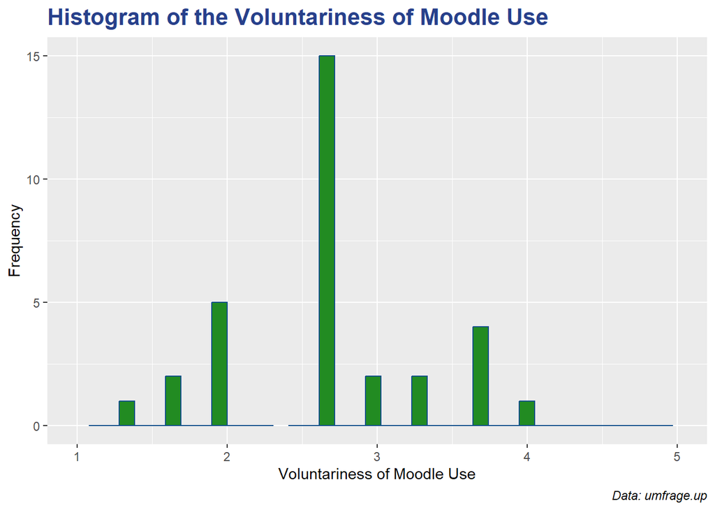

```r
# plot to show extent of voluntariness of Moodle use to determine whether AT/BI/AU are proper variables to use for statistical testing
plot_vol <- ggplot(data, aes(VU) ) +
              geom_histogram(na.rm = T,
                             colour = "dodgerblue4",  # contour color
                             fill   = "forestgreen",  # fill/insides color
                             bins  = 40) +
              xlim(1,5) +
              ylim(0,15) +
              labs(y = "Frequency",
                   x = "Voluntariness of Moodle Use",
                   caption = "Data: umfrage.up",
                   title = "Histogram of the Voluntariness of Moodle Use") +
              theme(plot.title    = element_text(color = "royalblue4",
                                     size = 16, face = "bold"),
              plot.caption  = element_text(face = "italic")  # text formatting
              )

plot_vol
```

```r
shapiro.test(data$VU) # normality cannot be assumed
```

```
##
##  Shapiro-Wilk normality test
##
## data:  data$VU
## W = 0.84956, p-value = 8.722e-07
```

```r
mean(data$VU)
```

```
## [1] 2.460784
```

```r
median(data$VU)
```

```
## [1] 2.333333
```

```r
skewness(data$VU) # symmetric enough for one-sample Wilcoxon test
```

```
## [1] 0.3039432
```

```r
wilcox.test(data$VU, mu = 3, alternative = "less")
```

```
##
##  Wilcoxon signed rank test with continuity correction
##
## data:  data$VU
## V = 222.5, p-value = 3.585e-09
## alternative hypothesis: true location is less than 3
```

The p-value is lwoer than the significance level alpha of 0.05. The null hypothesis can be rejected and I can assume that the use of Moodle is mandatory for the average student at the university of Potsdam as the median of the sample is lower than 3, 3 meaning that Moodle use is neither mandatory nor voluntary and a lower number meaning that Moodle use is mandatory. This means that for the investigation between academic discipline and technology acceptance, using the variable “actual use of Moodle” is not helpful as students can not choose to not use it. This means that high usage can’t indicate high acceptance. Instead, I will use perceived ease of use and perceived usefulness. I will also not use behavioral intention to use Moodle since this too is influenced by the lack of voluntariness.

## Hypothesis 1: Perceived Ease of Use and Perceived Usefulness

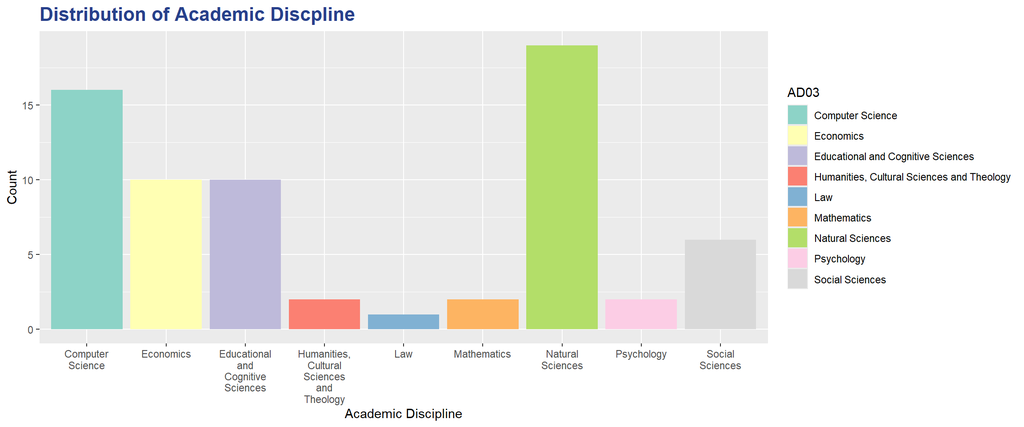

```r
# add labels to make plot more understandable
data$AD03 <- factor(data$AD03,
                    levels = c(1,2,3,4,5,6,7,8,9,10),
                    labels = c("Computer Science","Economics","Educational and Cognitive Sciences","Humanities, Cultural Sciences and Theology","Law","Mathematics","Natural Sciences","Psychology","Social Sciences","Sports and Health Science")
                    )

# plot to display distribution of academic discipline among participants of study
plot_ad_dis <- ggplot(data, aes(x = AD03, fill = AD03)) +
                geom_bar(position = "dodge") + # elements next to each other
                labs(title = "Distribution of Academic Discpline",
                     x = "Academic Discipline",
                     y = "Count") +
                scale_x_discrete(labels = label_wrap(10)) +
                scale_fill_brewer(palette = "Set3") +
                theme(plot.title    = element_text(color = "royalblue4",
                                                   size = 16, face = "bold"),
                plot.caption  = element_text(face = "italic")
                )

plot_ad_dis
```

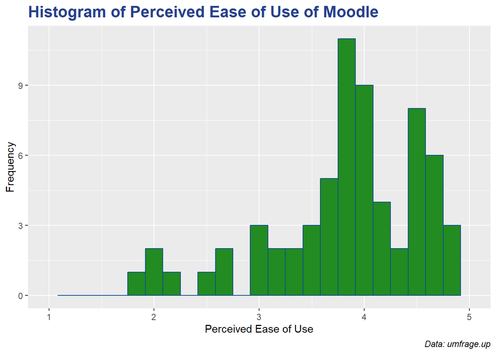

```r
# display perceived ease of use
hist1 <- ggplot(data, aes(PE) ) +
            geom_histogram(na.rm = T,
                           colour = "dodgerblue4",  # contour color
                           fill   = "forestgreen",  # fill/insides color
                           bins  = 25) +
            xlim(1,5) +
            labs(y = "Frequency",
                 x = "Perceived Ease of Use",
                 caption = "Data: umfrage.up",
                 title = "Histogram of Perceived Ease of Use of Moodle") +
            theme(plot.title    = element_text(color = "royalblue4",
                                               size = 16, face = "bold"),
                  plot.caption  = element_text(face = "italic")  # text formatting
                  )

# display perceived usefulness
hist2 <- ggplot(data, aes(PU) ) +
            geom_histogram(na.rm = T,
                           colour = "dodgerblue4",  # contour color
                           fill   = "forestgreen",  # fill/insides color
                           bins  = 25) +
            xlim(1,5) +
            labs(y = "Frequency",
                 x = "Perceived Usefulness",
                 caption = "Data: umfrage.up",
                 title = "Histogram of Perceived Usefulness of Moodle") +
            theme(plot.title    = element_text(color = "royalblue4",
                                               size = 16, face = "bold"),
                  plot.caption  = element_text(face = "italic")  # text formatting
                  )

hist1
```

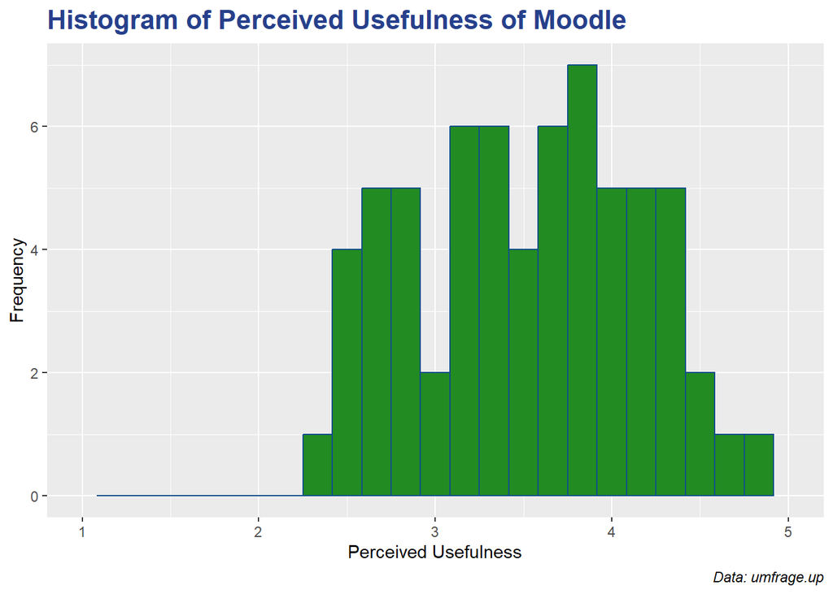

```r
hist2
```

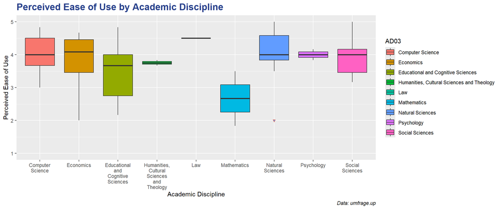

```r
# display perceived ease of use by academic discipline
plot_AD_PE <- ggplot(data, aes(x = AD03, y = PE, fill = AD03) )+
                geom_boxplot(coef = 2,  # length of whiskers
                             notchwidth = 0.5,
                             outlier.stroke = 0.7,  # boldness of outliers
                             outlier.size   = 1,
                             outlier.colour = "coral2",
                             outlier.shape  = 25  # triangle-shape
                             ) +
                ylim(1,5) +
                scale_x_discrete(labels = label_wrap(10)) +
                scale_color_brewer(type = "qual", palette = 2) +
                labs(title = "Perceived Ease of Use by Academic Discipline",
                     x = "Academic Discipline",
                     y = "Perceived Ease of Use",
                     caption = "Data: umfrage.up") +
                theme(plot.title    = element_text(color = "royalblue4", size = 16, face = "bold"),
                      plot.caption  = element_text(face = "italic")
                      )

plot_AD_PE
```

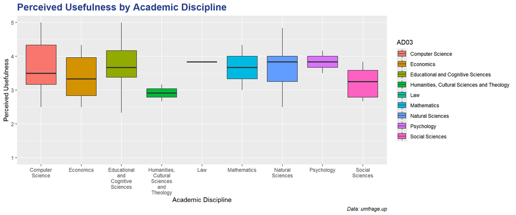

```r
# display perceived usefulness by academic discipline
plot_AD_PU <- ggplot(data, aes(x = AD03, y = PU, fill = AD03) )+
                geom_boxplot(coef = 2,  # length of whiskers
                             notchwidth = 0.5,
                             outlier.stroke = 0.7,  # boldness of outliers
                             outlier.size   = 1,
                             outlier.colour = "coral2",
                             outlier.shape  = 25  # 25 - triangles, nice shape
                             ) +
                ylim(1,5) +
                scale_x_discrete(labels = label_wrap(10)) +
                scale_color_brewer(type = "qual", palette = 3) +
                labs(title = "Perceived Usefulness by Academic Discipline",
                     x = "Academic Discipline",
                     y = "Perceived Usefulness",
                     caption = "Data: umfrage.up") +
                theme(plot.title    = element_text(color = "royalblue4", size = 16, face = "bold"),
                      plot.caption  = element_text(face = "italic")
                      )

plot_AD_PU
```

```r
# collect mean PE for every academic discipline
PE_mean <- aggregate(PE~AD03, data = data, mean)
PE_mean <- PE_mean[order(PE_mean$PE),]
PE_mean
```

```
##                                         AD03       PE
## 6                                Mathematics 2.666667
## 3         Educational and Cognitive Sciences 3.500000
## 4 Humanities, Cultural Sciences and Theology 3.750000
## 2                                  Economics 3.800000
## 9                            Social Sciences 3.944444
## 8                                 Psychology 4.000000
## 1                           Computer Science 4.020833
## 7                           Natural Sciences 4.070175
## 5                                        Law 4.500000
```

```r
# collect mean PU for every academic discipline
PU_mean <- aggregate(PU~AD03, data = data, mean)
PU_mean <- PU_mean[order(PU_mean$PU),]
PU_mean
```

```
##                                         AD03       PU
## 4 Humanities, Cultural Sciences and Theology 2.916667
## 9                            Social Sciences 3.222222
## 2                                  Economics 3.366667
## 7                           Natural Sciences 3.657895
## 6                                Mathematics 3.666667
## 3         Educational and Cognitive Sciences 3.700000
## 1                           Computer Science 3.718750
## 5                                        Law 3.833333
## 8                                 Psychology 3.833333
```

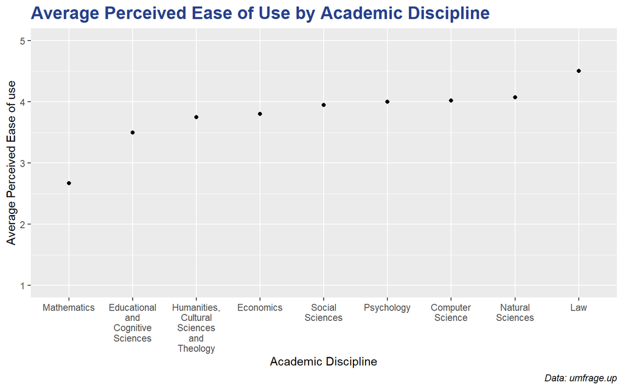

```r
# display mean PE by academic discipline
plot_AD_avgPE <- ggplot(PE_mean, aes(x = AD03, y = PE)) +
                  geom_point(na.rm = T) +
                  ylim(1,5) +
                  scale_x_discrete(limits = c("Mathematics","Educational and Cognitive Sciences","Humanities, Cultural Sciences and Theology","Economics","Social Sciences","Psychology","Computer Science","Natural Sciences","Law"), # force certain order of academic disciplines
                                   labels = label_wrap(10)) + # wrap names to prevent overlapping
                  labs(title = "Average Perceived Ease of Use by Academic Discipline",
                       x = "Academic Discipline",
                       y = "Average Perceived Ease of use",
                       caption = "Data: umfrage.up") +
                  theme(plot.title    = element_text(color = "royalblue4", size = 16, face = "bold"),
                        plot.caption  = element_text(face = "italic")
                        )

plot_AD_avgPE
```

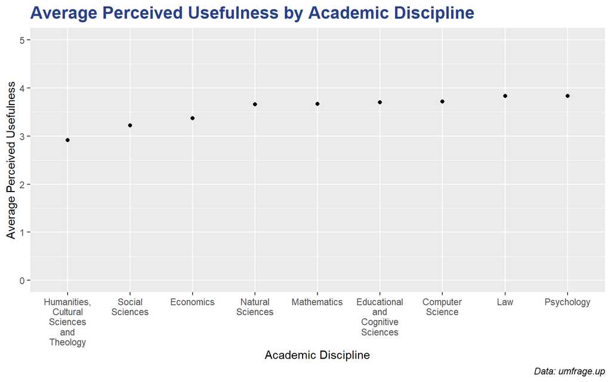

```r
# display mean PU by academic discipline
plot_AD_avgPU <- ggplot(PU_mean, aes(x = AD03, y = PU)) +
                  geom_point(na.rm = T) +
                  ylim(0,5) +
                  scale_x_discrete(limits = c("Humanities, Cultural Sciences and Theology","Social Sciences","Economics","Natural Sciences","Mathematics","Educational and Cognitive Sciences","Computer Science","Law","Psychology"),
                                   labels = label_wrap(10)) +
                  labs(title = "Average Perceived Usefulness by Academic Discipline",
                       x = "Academic Discipline",
                       y = "Average Perceived Usefulness",
                       caption = "Data: umfrage.up") +
                  theme(plot.title    = element_text(color = "royalblue4", size = 16, face = "bold"),
                        plot.caption  = element_text(face = "italic")
                        )

plot_AD_avgPU
```

Now I will investigate the relationship between average PE and PU per academic discipline.

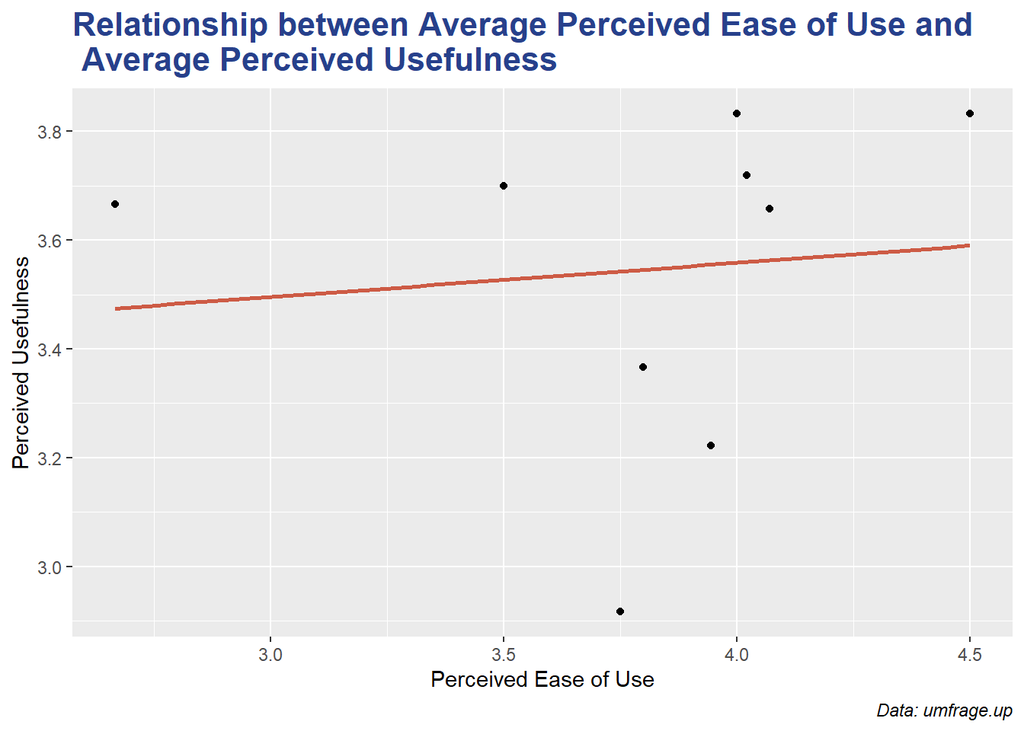

```r
# create table with average PE and PU per academic discipline
AD_PE_PU <- aggregate(PE~AD03, data = data, mean)
PU_temp <- aggregate(PU~AD03, data = data, mean)
AD_PE_PU$PU <- PU_temp$PU

# display relationship between PE and PU
plot_PE_PU <- ggplot(AD_PE_PU, aes(x = PE, y = PU)) +
                geom_point(na.rm = T) +  # a layer of points
                geom_smooth(na.rm = T,
                            method = "lm",   # linear model
                            se = F,
                            colour = "coral3",
                            show.legend = T) +
                labs(title = "Relationship between Average Perceived Ease of Use and \n Average Perceived Usefulness",
                     caption = "Data: umfrage.up",
                     x = "Perceived Ease of Use",
                     y = "Perceived Usefulness") +
                theme(plot.title = element_text(color = "royalblue4", size = 16, face = "bold"),
                      plot.caption  = element_text(face = "italic"))

plot_PE_PU
```

Now I will save the figures in a separate “results” folder.

```r
ggsave("histPE.png", plot = hist1, path = here("results"))
ggsave("histPU.png", plot = hist2, path = here("results"))
ggsave("plot_AD_avgPE.png", plot = plot_AD_avgPE, path = here("results"))
ggsave("plot_AD_avgPU.png", plot = plot_AD_avgPU, path = here("results"))
ggsave("plot_ad_dis.png", plot = plot_ad_dis, path = here("results"), width = 12)
ggsave("plot_AD_PE.png", plot = plot_AD_PE, path = here("results"), width = 12)
ggsave("plot_AD_PU.png", plot = plot_AD_PU, path = here("results"), width = 12)
ggsave("plot_PE_PU.png", plot = plot_PE_PU, path = here("results"))
ggsave("plot_vol.png", plot = plot_vol, path = here("results"))
```

### Hypothesis 1 Testing

To test hypothesis 1, I will use one-way ANOVA PE and PU are continuous dependent variables. There is one independent variable and it is categorical with 10 levels - academic discipline. According to this website (https://tales.nmc.unibas.ch/de/conducting-psychological-research-6/statistics-and-analyses-22/which-test-for-which-hypothesis-71), this means I use one-way ANOVA on PE and PU separately.The requirement is that the dependent variable is normally distributed in every level and that these normal populations have common variance which can be tested using Levene’s test.

```r
PE.aov <- aov(PE ~ AD03, data = data)
summary(PE.aov)
```

```
##             Df Sum Sq Mean Sq F value Pr(>F)
## AD03         8   5.93  0.7410   1.371  0.228
## Residuals   59  31.88  0.5404
```

```r
PU.aov <- aov(PU ~ AD03, data = data)
summary(PU.aov)
```

```
##             Df Sum Sq Mean Sq F value Pr(>F)
## AD03         8  2.877  0.3597   0.736  0.659
## Residuals   59 28.817  0.4884
```

```r
# testing AT and BI is more for insurance that I wasn't wrong to exclude it, wont be included in report
AT.aov <- aov(AT ~ AD03, data = data)
summary(AT.aov)
```

```
##             Df Sum Sq Mean Sq F value Pr(>F)
## AD03         8   4.28  0.5352   0.663  0.721
## Residuals   59  47.59  0.8067
```

```r
BI.aov <- aov(BI ~ AD03, data = data)
summary(BI.aov)
```

```
##             Df Sum Sq Mean Sq F value Pr(>F)
## AD03         8  7.025  0.8782   1.741  0.108
## Residuals   59 29.762  0.5044
```

```r
# tests homogeneity of variance (assumption to use one-way ANOVA)
leveneTest(PE ~ AD03, data = data)
```

```
## Levene's Test for Homogeneity of Variance (center = median)
##       Df F value Pr(>F)
## group  8  0.9917 0.4519
##       59
```

```r
leveneTest(PU ~ AD03, data = data)
```

```
## Levene's Test for Homogeneity of Variance (center = median)
##       Df F value Pr(>F)
## group  8  0.7287 0.6656
##       59
```

```r
leveneTest(AT ~ AD03, data = data)
```

```
## Levene's Test for Homogeneity of Variance (center = median)
##       Df F value Pr(>F)
## group  8   0.543 0.8193
##       59
```

```r
leveneTest(BI ~ AD03, data = data)
```

```
## Levene's Test for Homogeneity of Variance (center = median)
##       Df F value Pr(>F)
## group  8  0.8789 0.5396
##       59
```

Since the p-values are above 0.05 for each model, the homogeneity of variances can be assumed.

```r
PE.res <- residuals(object = PE.aov)
PU.res <- residuals(object = PU.aov)
AT.res <- residuals(object = AT.aov)
BI.res <- residuals(object = BI.aov)

# test normality (assumption to use one-way ANOVA)
shapiro.test(x = PE.res)
```

```
##
##  Shapiro-Wilk normality test
##
## data:  PE.res
## W = 0.96706, p-value = 0.06894
```

```r
shapiro.test(x = PU.res)
```

```
##
##  Shapiro-Wilk normality test
##
## data:  PU.res
## W = 0.98092, p-value = 0.3829
```

```r
shapiro.test(x = AT.res)
```

```
##
##  Shapiro-Wilk normality test
##
## data:  AT.res
## W = 0.97111, p-value = 0.1154
```

```r
shapiro.test(x = BI.res)
```

```
##
##  Shapiro-Wilk normality test
##
## data:  BI.res
## W = 0.9662, p-value = 0.06189
```

According to the Shapiro-Wilk normality test, it can be assumed that the normality requirement is not violated.

This means that the one-way ANOVA can be applied here and this also means that there is no indication that there is a statistical significance between PE, PU, AT and BI and academic discipline.

This is from here: http://www.sthda.com/english/wiki/one-way-anova-test-in-r

## Descriptive Statistics

```r
summary(data[c("AD01","AD02","AD03","DE02","DE03","AT","BI","PE","PU","VU","AU")])
```

```
##  AD01      AD02                                            AD03       DE02
##  1:68   1    :49   Natural Sciences                          :19   1    :30
##         2    :18   Computer Science                          :16   2    :34
##         Other: 1   Economics                                 :10   3    : 2
##                    Educational and Cognitive Sciences        :10   Other: 2
##                    Social Sciences                           : 6
##                    Humanities, Cultural Sciences and Theology: 2
##                    (Other)                                   : 5
##     DE03          AT             BI              PE              PU
##  1    :48   Min.   :1.00   Min.   :1.800   Min.   :1.833   Min.   :2.333
##  2    :17   1st Qu.:2.25   1st Qu.:3.200   1st Qu.:3.625   1st Qu.:3.125
##  3    : 1   Median :3.00   Median :3.600   Median :4.000   Median :3.667
##  4    : 1   Mean   :3.00   Mean   :3.556   Mean   :3.877   Mean   :3.583
##  Other: 1   3rd Qu.:3.50   3rd Qu.:4.000   3rd Qu.:4.500   3rd Qu.:4.042
##             Max.   :5.00   Max.   :5.000   Max.   :5.000   Max.   :5.000
##
##        VU              AU
##  Min.   :1.000   Min.   :1.333
##  1st Qu.:2.333   1st Qu.:3.000
##  Median :2.333   Median :4.000
##  Mean   :2.461   Mean   :3.804
##  3rd Qu.:2.667   3rd Qu.:4.000
##  Max.   :4.000   Max.   :5.000
##
```

## Hypothesis 2: Voluntariness (cont.)

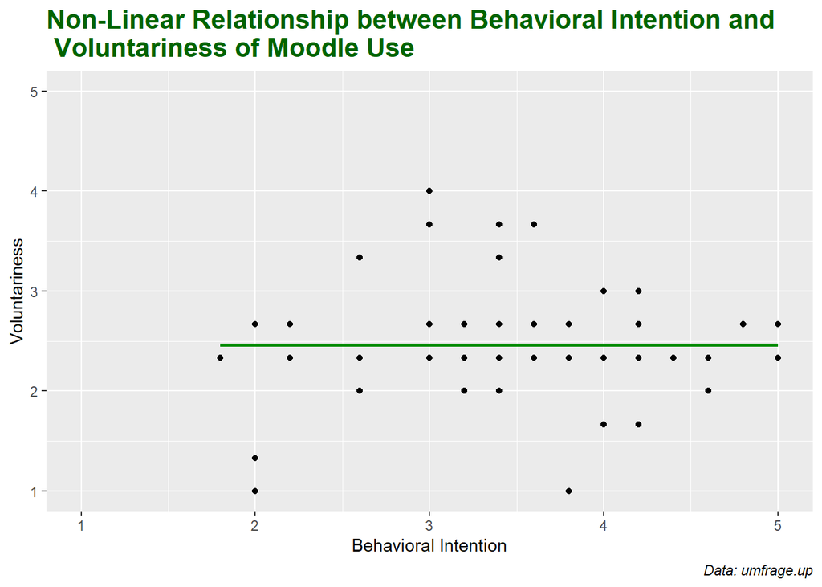

```r
# display relationship between voluntariness and behavioral intention
plot_BI_VU <- ggplot(data, aes(x = BI, y = VU)) +  # label = Name
                geom_point(na.rm = T) +  # a layer of points
                ylim(1,5) +
                xlim(1,5) +
                geom_smooth(na.rm = T,
                            method = "lm",   # linear model
                            se = F,
                            colour = "green4",
                            show.legend = T) +
                labs(title = "Non-Linear Relationship between Behavioral Intention and \n Voluntariness of Moodle Use",
                     caption = "Data: umfrage.up",
                     x = "Behavioral Intention",
                     y = "Voluntariness") +
                theme(plot.title = element_text(color = "darkgreen", size = 16, face = "bold"),
                      plot.caption  = element_text(face = "italic"))

plot_BI_VU
```

```r
ggsave("plot_BI_VU.png", plot = plot_BI_VU, path = here("results"))
```

## Hypothesis 3: Personal Ecosystems

```r
# check answers for what devices / software participants use for their studies
data$OT01_02
```

```
##  [1] ""
##  [2] "iPad,Laptop, PC, Anki"
##  [3] ""
##  [4] "Organisation, Material der Dozierenden "
##  [5] "Laptop, Tablet, Dektop-Computer, Handy"
##  [6] "Laptop"
##  [7] "Linux-Laptop, WIndows-Laptop, Android-Tablet, Anki, Jupyter, Python, R, Stata"
##  [8] "Laptop, iPad"
##  [9] "Laptop, Office-Paket, Moodle, Puls, Doodle, Mentimeter, Box.Up, Zotero, VPN der Uni, Umfragen UP (SoSciSurvey), Unipark, ERIC, PsychInfo, Homepage der Uni"
## [10] "PC, Handy, Tablet"
## [11] "Tablet, Laptop, PC, Handy, Anki, StudySmarter, Studocu, ChatGPT, Samsung Notes, Microsoft Copilot"
## [12] "Notion, Anki, Smartphone, Tablet, Laptop, GitLab/GitHub"
## [13] "Laptop, Computer, Smartphone, Anki, Word, Excel, PowerPoint, VSCode, Moodle"
## [14] "Laptop, Tablet, PC, Samsung Notes, Moodle, VSCode, Google Kalender, Google Drive, Discord"
## [15] "MacBook, iPad, GoodNotes, MS Office, Google Scholar, OneDrive"
```

[output cut: 53 more lines]

```r
# manually add number of parts in personal ecosystem from OT01_02
data$OT_number <- c(NA,4,NA,NA,4,1,7,2,14,3,10,6,7,9,6,5,4,14,2,1,3,7,9,4,9,6,11,2,4,12,4,2,1,14,1,4,9,4,11,2,3,1,9,1,2,11,5,11,14,3,6,9,4,5,NA,4,NA,3,4,4,6,6,5,9,2,4,2,5)

# make new data frame with needed columns
OT_data <- data[,c("ID","AT","BI","PE","PU","VU","OT_number","AD03")]

# remove columns containing NAs
OT_data_new <- na.omit(OT_data)

# mean number of parts of personal ecosystems
OT_mean <- aggregate(OT_number~AD03, data = OT_data_new, mean)
OT_mean
```

```
##                                         AD03 OT_number
## 1                           Computer Science  5.214286
## 2                                  Economics  5.400000
## 3         Educational and Cognitive Sciences  6.666667
## 4 Humanities, Cultural Sciences and Theology  4.000000
## 5                                        Law  2.000000
## 6                                Mathematics  6.000000
## 7                           Natural Sciences  6.052632
## 8                                 Psychology  6.000000
## 9                            Social Sciences  5.000000
```

```r
# one-way ANOVA test
OT.aov <- aov(OT_number ~ AD03, data = OT_data_new)
summary(OT.aov)
```

```
##             Df Sum Sq Mean Sq F value Pr(>F)
## AD03         8   34.6   4.327   0.288  0.967
## Residuals   54  811.7  15.032
```

```r
# test assumptions for one-way ANOVA
leveneTest(OT_number ~ AD03, data = OT_data_new)
```

```
## Levene's Test for Homogeneity of Variance (center = median)
##       Df F value Pr(>F)
## group  8  1.3773 0.2275
##       54
```

```r
OT.res <- residuals(object = OT.aov)
shapiro.test(x = OT.res)
```

```
##
##  Shapiro-Wilk normality test
##
## data:  OT.res
## W = 0.94286, p-value = 0.005633
```

I cannot use one-way ANOVA since the normality assumption is violated. The Kruskal-Wallis rank sum test can be used instead.

```r
# alternative to one-way ANOVA
kruskal.test(OT_number ~ AD03, data = OT_data_new)
```

```
##
##  Kruskal-Wallis rank sum test
##
## data:  OT_number by AD03
## Kruskal-Wallis chi-squared = 2.4655, df = 8, p-value = 0.9633
```

Since the p-value is above 0.05, it can be assumed that there is no difference in how many devices / pieces of software students use by academic discipline.

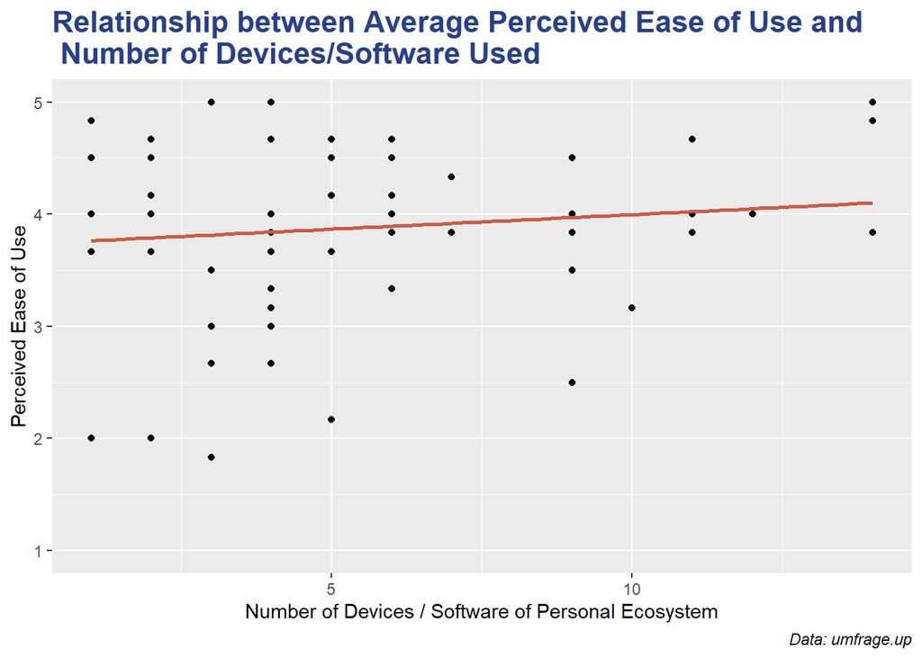

```r
# display relationship between OT number and PE
plot_OT_PE <- ggplot(OT_data_new, aes(x = OT_number, y = PE)) +
                geom_point(na.rm = T) +
                ylim(1,5) +
                geom_smooth(na.rm = T,
                            method = "lm",
                            se = F,
                            colour = "coral3",
                            show.legend = T) +
                labs(title = "Relationship between Average Perceived Ease of Use and \n Number of Devices/Software Used",
                     caption = "Data: umfrage.up",
                     x = "Number of Devices / Software of Personal Ecosystem",
                     y = "Perceived Ease of Use") +
                theme(plot.title = element_text(color = "royalblue4", size = 16, face = "bold"),
                      plot.caption  = element_text(face = "italic"))

plot_OT_PE
```

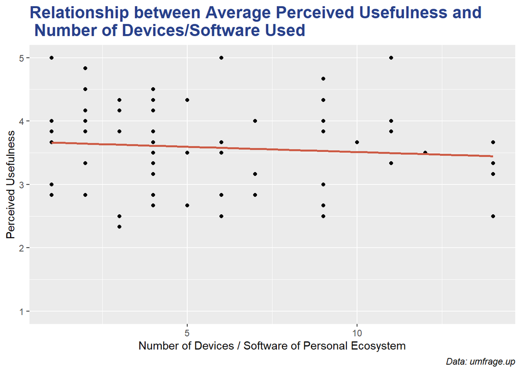

```r
# display relationship between OT numbers and PU
plot_OT_PU <- ggplot(OT_data_new, aes(x = OT_number, y = PU)) +
                geom_point(na.rm = T) +
                ylim(1,5) +
                geom_smooth(na.rm = T,
                            method = "lm",
                            se = F,
                            colour = "coral3",
                            show.legend = T) +
                labs(title = "Relationship between Average Perceived Usefulness and \n Number of Devices/Software Used",
                     caption = "Data: umfrage.up",
                     x = "Number of Devices / Software of Personal Ecosystem",
                     y = "Perceived Usefulness") +
                theme(plot.title = element_text(color = "royalblue4", size = 16, face = "bold"),
                      plot.caption  = element_text(face = "italic"))

plot_OT_PU
```

```r
# linear models for OT numbers an PE and OT numbers and PU
OT_PE_lm <- lm(OT_number~PE, data=OT_data_new)
summary(OT_PE_lm)
```

```
##
## Call:
## lm(formula = OT_number ~ PE, data = OT_data_new)
##
## Residuals:
##    Min     1Q Median     3Q    Max
## -5.218 -2.370 -1.119  2.981  8.379
##
## Coefficients:
##             Estimate Std. Error t value Pr(>|t|)
## (Intercept)   3.3293     2.4145   1.379    0.173
## PE            0.5978     0.6101   0.980    0.331
##
## Residual standard error: 3.696 on 61 degrees of freedom
## Multiple R-squared:  0.0155, Adjusted R-squared:  -0.0006435
## F-statistic: 0.9601 on 1 and 61 DF,  p-value: 0.331
```

```r
OT_PU_lm <- lm(OT_number~PU, data=OT_data_new)
summary(OT_PU_lm)
```

```
##
## Call:
## lm(formula = OT_number ~ PU, data = OT_data_new)
##
## Residuals:
##    Min     1Q Median     3Q    Max
## -4.995 -2.808 -1.231  2.890  8.387
##
## Coefficients:
##             Estimate Std. Error t value Pr(>|t|)
## (Intercept)   7.2932     2.4537   2.972  0.00423 **
## PU           -0.4582     0.6720  -0.682  0.49793
## ---
## Signif. codes:  0 '***' 0.001 '**' 0.01 '*' 0.05 '.' 0.1 ' ' 1
##
## Residual standard error: 3.711 on 61 degrees of freedom
## Multiple R-squared:  0.007563,   Adjusted R-squared:  -0.008706
## F-statistic: 0.4649 on 1 and 61 DF,  p-value: 0.4979
```

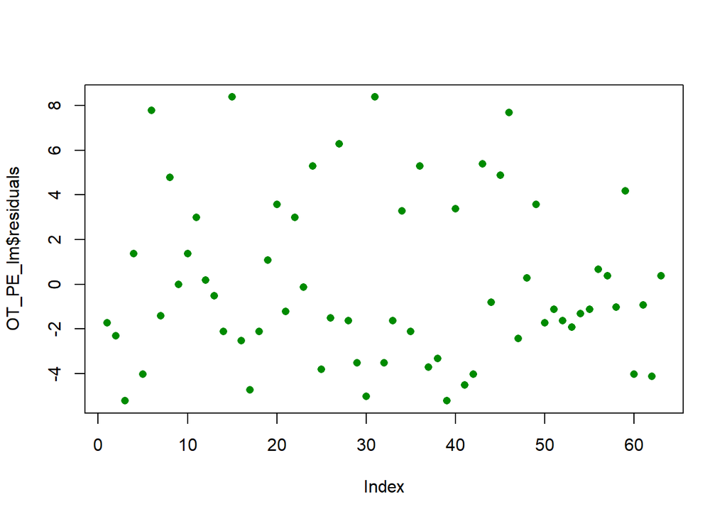

```r
plot(OT_PE_lm$residuals, pch = 16, col = "green4")
```

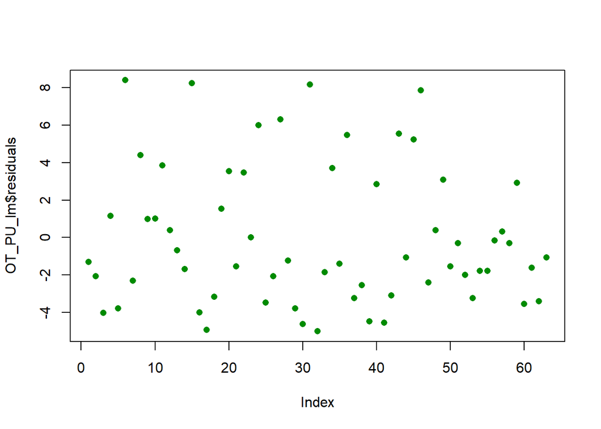

```r
plot(OT_PU_lm$residuals, pch = 16, col = "green4")
```

### Checking Assumptions for Linear Regression

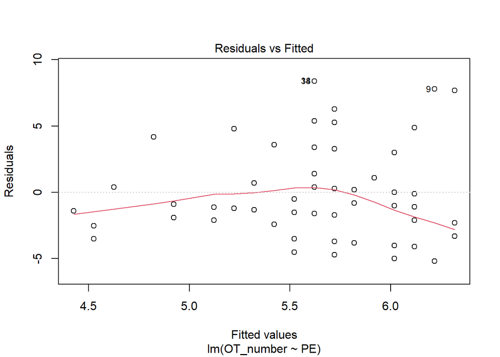

```r
# check linearity
plot(OT_PE_lm, 1)
```

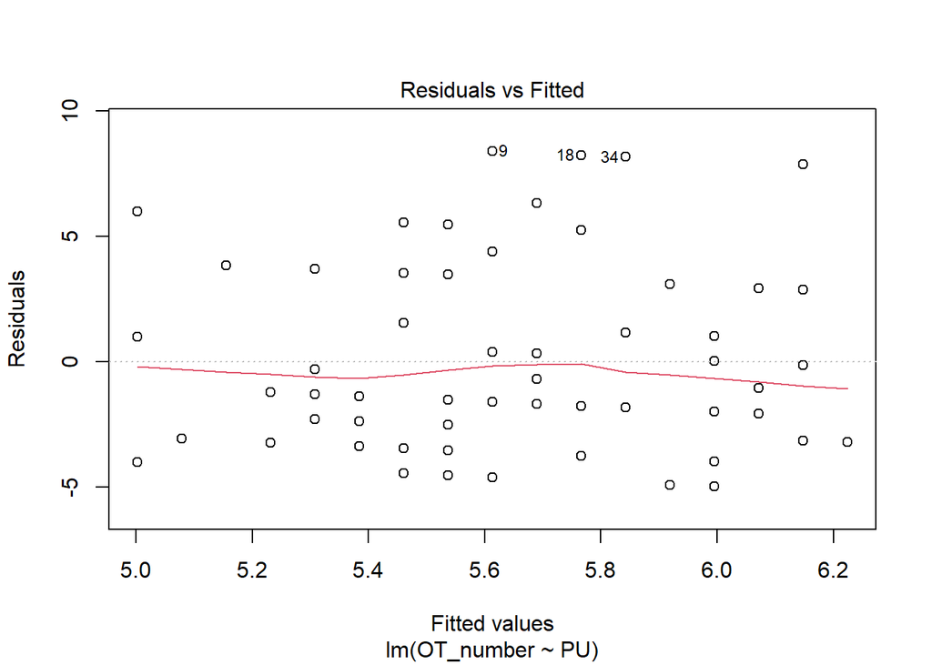

```r
plot(OT_PU_lm, 1)
```

```r
# independence between variables
durbinWatsonTest(OT_PE_lm)
```

```
##  lag Autocorrelation D-W Statistic p-value
##    1      -0.2298462      2.455971   0.048
##  Alternative hypothesis: rho != 0
```

```r
durbinWatsonTest(OT_PU_lm)
```

```
##  lag Autocorrelation D-W Statistic p-value
##    1      -0.2033819      2.403361   0.098
##  Alternative hypothesis: rho != 0
```

I can’t use linear regression since not all assumptions are met.

```r
# normality test
shapiro.test(OT_data_new$OT_number)
```

```
##
##  Shapiro-Wilk normality test
##
## data:  OT_data_new$OT_number
## W = 0.90542, p-value = 0.0001452
```

```r
shapiro.test(OT_data_new$PE)
```

```
##
##  Shapiro-Wilk normality test
##
## data:  OT_data_new$PE
## W = 0.92461, p-value = 0.0008639
```

```r
shapiro.test(OT_data_new$PU)
```

```
##
##  Shapiro-Wilk normality test
##
## data:  OT_data_new$PU
## W = 0.96839, p-value = 0.1048
```

I also can’t use Pearson correlation test since OT_number and PE are not necessarily normally distributed.

```r
# Kendall tau correlation test
K.PE.res <- cor.test(OT_data_new$OT_number, OT_data_new$PE,  method="kendall")
K.PE.res
```

```
##
##  Kendall's rank correlation tau
##
## data:  OT_data_new$OT_number and OT_data_new$PE
## z = 0.31292, p-value = 0.7543
## alternative hypothesis: true tau is not equal to 0
## sample estimates:
##        tau
## 0.02915847
```

```r
K.PU.res <- cor.test(OT_data_new$OT_number, OT_data_new$PU,  method="kendall")
K.PU.res
```

```
##
##  Kendall's rank correlation tau
##
## data:  OT_data_new$OT_number and OT_data_new$PU
## z = -0.8524, p-value = 0.394
## alternative hypothesis: true tau is not equal to 0
## sample estimates:
##         tau
## -0.07890741
```

It can be assumed that OT_number an PE, and OT_number and PU are not correlated.